# Olive Rockfish

*Sebastes serranoides*

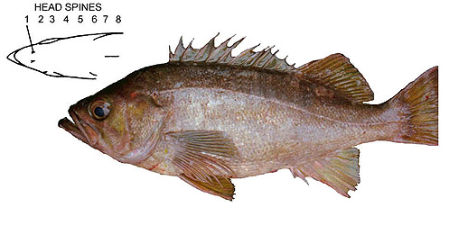

**Body color:** Dark olive-gray dorsally becoming lighter gray on lower sides and white ventrally; clear splotches evident along the top of back; sides finely speckled w/ dark gray; fins dark olive w/ yellow.

**Peritoneum color:** light **Shape between eyes:** convex

**Counts:** D:XII-XIII,15-17, Ar:8-10, P1:17-19, GR:29-36, LLp:50-57, LLs:?-?, V:26

**Occurence:** Oregon - Baja California

**Depth:** 146 meters **Size:** 61 cm **Species code:** 30510

**Similar species:**

- *Yellowtail rockfish* - anal rays typically 8 (typically 9 in Olive RF); less prominent pale areas on back; pectoral rays often edged w/ pink (none in Olive RF); pectoral rays typically 18 (typically 17 in Olive RF)
- *Widow rockfish* - anal-fin margin w/ strong posterior slant; fin membranes black; peritoneum dark; anal rays typically 8 (typically 9 in Olive RF); pectoral rays typically 18 (typically 17 in Olive RF); mouth small, maxilla to midorbit (well past midorbit in Olive RF)
- *Black rockfish* - anal-fin margin rounded; body color black to blue-black, white ventrally; pectoral rays typically 19 (typically 17 in Olive RF); anal rays typically 8 (typically 9 in Olive RF)

Back to Group

**Corrections:** If you see mistakes or want to suggest changes, please create an [issue](https://github.com/zoyafuso-NOAA/RACE_Survey_App/issues) on the source repository or

*reach out to Liz Dawson (Liz.Dawson AT noaa.gov).*